# IMF Online Course: Macroeconomic forecasting

## Module 3B: Statistical Properties of Time Series Data

### Testing for Nonstationarity and Unit Roots

**Author**: Miha Trošt  
**Date**: 29-01-2016

```r
# useful libraries
library(plyr)
library(dplyr)
library(forecast)
library(stringr)
library(lubridate)
library(tidyr)
library(broom)
library(urca)
```

```r
my_wd <-
  "C:/Users/Miha/Documents/GitHub/IMF_Macro_Forecasting_R/002_module_3a_Statistical_properties_of_time_series/Module3_data/"

# m3_data <-
#   read.csv(str_c(my_wd, "module3_data_Identifying_ARMA.csv"),
#            sep = ",")

my_df <-
  read.csv(str_c(my_wd, "module3_data_PE_Ratios.csv"),
           sep = ",",
           stringsAsFactors = FALSE)
#
# my_non_st_df <-
#   read.csv(str_c(my_wd, "module3b_data_Simulated_Nonstationary.CSV"),
#            sep = ",",
#            stringsAsFactors = FALSE)
```

### Stationarity or Nonstationarity?

Optional: Replicate the results in the table below. Use the command pe_ind.uroot(adf,exo=const) and pe_ind.uroot(adf,exog=trend) to replicate the results for the ADF test with a constant and with a constant and a trend respectively. You can change the “adf” option to “pp” to produce the PP tests.

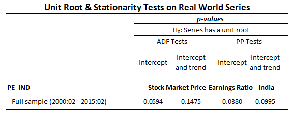

#### Replicating the table with unit root tests

```r
my_pe_ind_df <-
  my_df %>%
  select(date, pe_ind) %>%
  filter(complete.cases(.))

my_lags <- 5
stationarity_tests <- list()

# ADF unit root test

stationarity_tests$adf_drift <-
  ur.df(my_pe_ind_df$pe_ind, type = "drift",
        lags = my_lags, selectlags = "AIC") %>%
  summary

stationarity_tests$adf_trend <-
  ur.df(my_pe_ind_df$pe_ind, type = "trend",
        lags = my_lags, selectlags = "AIC") %>%
  summary

# Phillips - Perron unit root test

stationarity_tests$pp_constant <-
  ur.pp(my_pe_ind_df$pe_ind,
        type = "Z-tau", model = "constant", lags = "long") %>%
  summary

stationarity_tests$pp_trend <-
  ur.pp(my_pe_ind_df$pe_ind,
        type = "Z-tau", model = "trend", lags = "long") %>%
  summary

# KPSS stationarity test

stationarity_tests$kpss_mu <-
  ur.kpss(my_pe_ind_df$pe_ind, type = "mu", lags = "long") %>%
  summary

stationarity_tests$kpss_tau <-
  ur.kpss(my_pe_ind_df$pe_ind, type = "tau", lags = "long") %>%
  summary
```

#### QUESTION 3.40

Given that in both cases the coefficient on the trend term is not statistically significant, using a 10 percent level of significance, the test results suggest that pe_ind is:

```r
stationarity_tests[1:4]
```

```
$adf_drift

###############################################
# Augmented Dickey-Fuller Test Unit Root Test #
###############################################

Test regression drift


Call:
lm(formula = z.diff ~ z.lag.1 + 1 + z.diff.lag)

Residuals:
    Min      1Q  Median      3Q     Max
-3.5587 -0.7058 -0.0642  0.7567  5.8410

Coefficients:
            Estimate Std. Error t value Pr(>|t|)
(Intercept)  1.74494    0.55875   3.123  0.00210 **
z.lag.1     -0.09926    0.03194  -3.107  0.00221 **
z.diff.lag   0.10836    0.07540   1.437  0.15246
---
Signif. codes:  0 '***' 0.001 '**' 0.01 '*' 0.05 '.' 0.1 ' ' 1

Residual standard error: 1.332 on 173 degrees of freedom
Multiple R-squared:  0.05628,   Adjusted R-squared:  0.04537
F-statistic: 5.158 on 2 and 173 DF,  p-value: 0.00667


Value of test-statistic is: -3.1073 4.8957

Critical values for test statistics:
      1pct  5pct 10pct
tau2 -3.46 -2.88 -2.57
phi1  6.52  4.63  3.81


$adf_trend

###############################################
```

[output cut: 97 more lines]

```

Residual standard error: 1.342 on 178 degrees of freedom
Multiple R-squared:  0.8286,    Adjusted R-squared:  0.8267
F-statistic: 430.3 on 2 and 178 DF,  p-value: < 2.2e-16


Value of test-statistic, type: Z-tau  is: -3.1543

           aux. Z statistics
Z-tau-mu              2.3693
Z-tau-beta            1.0255

Critical values for Z statistics:
                     1pct      5pct    10pct
critical values -4.011397 -3.435459 -3.14149
```

Answer: Stationary

#### QUESTION 3.41

Run the KPSS test for pe_ind (see question 3.40 and replace “adf” with “kpss” in the command options of uroot). Based on the result, the variable pe_ind is (Hint: If the KPSS statistic is smaller than the x% level critical value then one cannot reject the null-hypothesis at the x% level and recall that the null hypothesis is that pe_ind is stationary):

Using a 10 percent level of significance, the KPSS test implies that pe_ind is:

```r
stationarity_tests[5:6]
```

```
$kpss_mu

#######################
# KPSS Unit Root Test #
#######################

Test is of type: mu with 13 lags.

Value of test-statistic is: 0.2369

Critical value for a significance level of:
                10pct  5pct 2.5pct  1pct
critical values 0.347 0.463  0.574 0.739


$kpss_tau

#######################
# KPSS Unit Root Test #
#######################

Test is of type: tau with 13 lags.

Value of test-statistic is: 0.082

Critical value for a significance level of:
                10pct  5pct 2.5pct  1pct
critical values 0.119 0.146  0.176 0.216
```

Answer: Stationary

### Video lecture

Create near unit root series: y

Trend stationary series: x

x<sub>t</sub> = 0.5 + 0.75 * x<sub>t-1</sub> + 0.01 * trend + e<sub>t</sub>; e<sub>t</sub> = rnorm(n, 0, 1.5)

Random walk series: z

z<sub>t</sub> = 0.8 + z<sub>t-1</sub> + e<sub>t</sub>; e<sub>t</sub> = rnorm(n, 0, 1)

```r
# number of observations in simulation
n <- 1382

# Near unit root series: y
y <- vector()
y <- 0

e_y <- rnorm(n, sd = 2)

for(i in 2:n){

  y[i] <- 0.5 + 0.96 * y[i - 1] + e_y[i]

}

# Trend stationary series: x
x <- vector()
x <- 0

e_x <- rnorm(n, sd = 1.5)
trend <- 1:n

for(i in 2:n){

  x[i] <- 0.5 + 0.75 * x[i - 1] + 0.01 * trend[i] + e_x[i]

}

# Random walk series: z
z <- vector()
z <- 0

e_z <- rnorm(n)

for(i in 2:n){

  z[i] <- 0.8 + 1 * z[i - 1] + e_z[i]

}
```

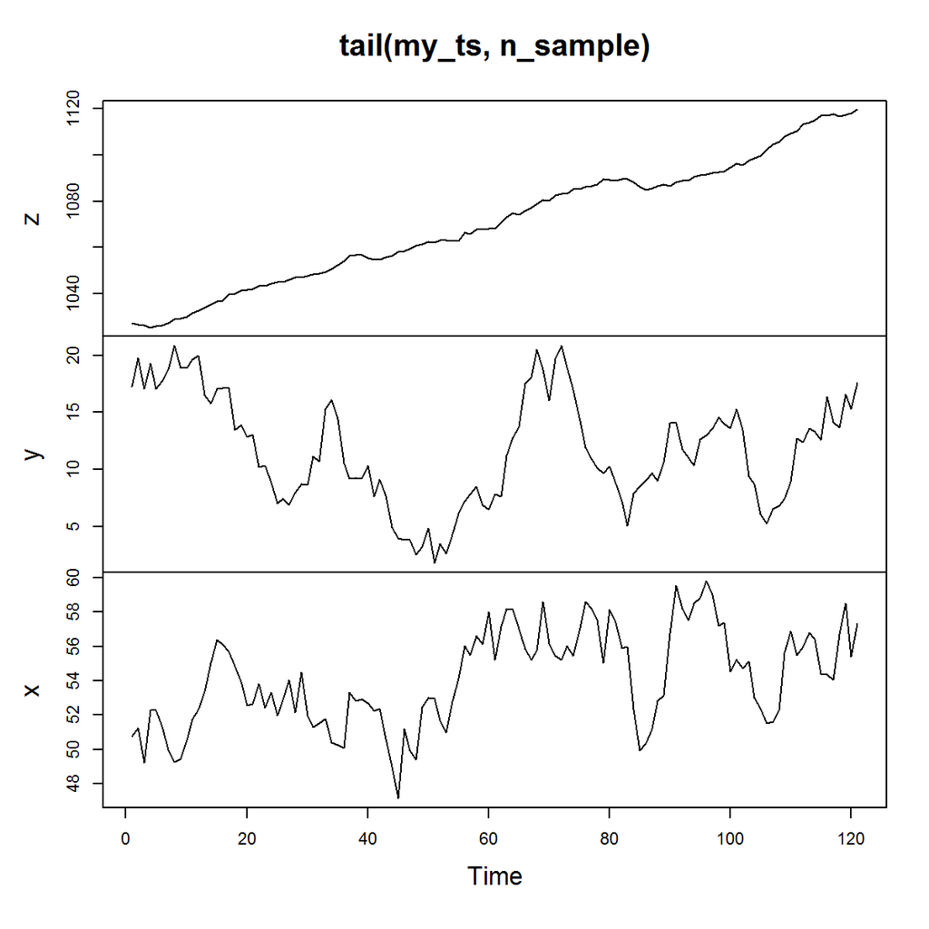

```r
# number of observations in sample
n_sample <- 121

my_ts <- cbind(z, y, x)

# plot last n_sample observations
plot.ts(tail(my_ts, n_sample))
```

### Stationarity test: ADF, PP, KPSS

```r
my_ts_df <-
  my_ts %>%
  as.data.frame

my_lags <- 5
stationarity_tests <- list()

# ADF unit root test

stationarity_tests$adf_none <-
  lapply(my_ts_df,
         function(x) {ur.df(x,
                            type = "none",
                            lags = my_lags,
                            selectlags = "AIC") %>% summary
           }
         )

stationarity_tests$adf_drift <-
  lapply(my_ts_df,
         function(x) {ur.df(x,
                            type = "drift",
                            lags = my_lags,
                            selectlags = "AIC") %>% summary
           }
         )

stationarity_tests$adf_trend <-
  lapply(my_ts_df,
         function(x) {ur.df(x,
                            type = "trend",
                            lags = my_lags,
                            selectlags = "AIC") %>% summary
           }
         )

# Phillips - Perron unit root test

stationarity_tests$pp_constant <-
  lapply(my_ts_df,
         function(x) {ur.pp(x,
                            type = "Z-tau",
                            model = "constant",
                            lags = "long") %>%  summary
           }
         )

stationarity_tests$pp_trend <-
  lapply(my_ts_df,
         function(x) {ur.pp(x,
                            type = "Z-tau",
                            model = "trend",
                            lags = "long") %>%  summary
           }
         )

# KPSS stationarity test

stationarity_tests$kpss_mu <-
  lapply(my_ts_df,
         function(x){ur.kpss(x,
                             type = "mu",
                             lags = "long") %>%  summary
           }
         )

stationarity_tests$kpss_tau <-
  lapply(my_ts_df,
         function(x){ur.kpss(x,
                             type = "tau",
                             lags = "long") %>%  summary
           }
         )

stationarity_tests
```

```
$adf_none
$adf_none$z

###############################################
# Augmented Dickey-Fuller Test Unit Root Test #
###############################################

Test regression none


Call:
lm(formula = z.diff ~ z.lag.1 - 1 + z.diff.lag)

Residuals:
    Min      1Q  Median      3Q     Max
-3.0882 -0.6005  0.1459  0.8347  3.7779

Coefficients:
             Estimate Std. Error t value Pr(>|t|)
z.lag.1     5.605e-04  6.464e-05   8.670  < 2e-16 ***
z.diff.lag1 9.762e-02  2.692e-02   3.627 0.000298 ***
z.diff.lag2 1.051e-01  2.689e-02   3.910 9.68e-05 ***
z.diff.lag3 6.874e-02  2.698e-02   2.548 0.010937 *
z.diff.lag4 1.070e-01  2.691e-02   3.976 7.36e-05 ***
z.diff.lag5 8.348e-02  2.694e-02   3.099 0.001980 **
---
Signif. codes:  0 '***' 0.001 '**' 0.01 '*' 0.05 '.' 0.1 ' ' 1

Residual standard error: 1.049 on 1370 degrees of freedom
Multiple R-squared:  0.3364,    Adjusted R-squared:  0.3335
F-statistic: 115.8 on 6 and 1370 DF,  p-value: < 2.2e-16


Value of test-statistic is: 8.6698

Critical values for test statistics:
      1pct  5pct 10pct
tau1 -2.58 -1.95 -1.62


```

[output cut: 627 more lines]

```


$kpss_tau$x

#######################
# KPSS Unit Root Test #
#######################

Test is of type: tau with 23 lags.

Value of test-statistic is: 0.0329

Critical value for a significance level of:
                10pct  5pct 2.5pct  1pct
critical values 0.119 0.146  0.176 0.216
```

### Running Different Tests

Open the EViews workfile “Module3B_data.wf1”, pagefile “Simulated_full_sample”.

During the video lecture, we conducted tests on three simulated series: y (a near-unit root series), z (a random walk) and x (a trend stationary series). Using the full sample of data (1,381 observations), the goal of this section is to ascertain that z is I(1) by running the three tests (ADF, PP, and KPSS) on its first-difference.

#### QUESTION 3.42

For the first difference of z, do the ADF or PP tests fail to reject the null hypothesis of a unit root for any of the specifications (constant/constant and trend)?

Hint: Please note that by adding the option “dif=1” in the uroot command, EViews runs the test for the first difference of the variable e.g. z.uroot(adf,exog=trend,dif=1) for the ADF test of z with a constant and a trend (with a constant only replace “exog=trend” with “exog=const”). You can change the “adf” option to “pp” to produce the PP tests.

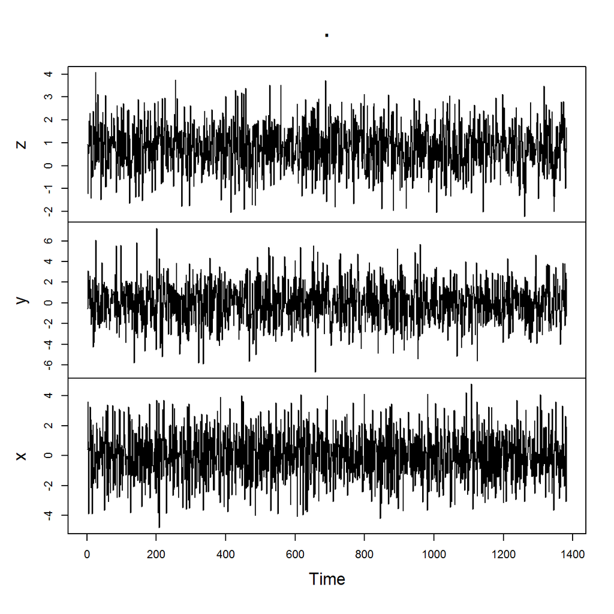

```r
my_diff_ts <-
  my_ts_df %>%
  mutate_each(funs(. - lag(., 1)))

my_diff_ts %>%
  plot.ts
```

All time series x, y, z appear to be stationary in first differences.

```r
my_df <-
  my_diff_ts %>%
  filter(complete.cases(.)) %>%
  select(z) %>%
  unlist %>%
  unname

my_lags <- 5

stationarity_tests_diff <- list()

# ADF unit root test

stationarity_tests_diff$adf_drift <-
  ur.df(my_df, type = "drift",
        lags = my_lags, selectlags = "AIC") %>%
  summary

stationarity_tests_diff$adf_trend <-
  ur.df(my_df, type = "trend",
        lags = my_lags, selectlags = "AIC") %>%
  summary

# Phillips - Perron unit root test

stationarity_tests_diff$pp_constant <-
  ur.pp(my_df,
        type = "Z-tau", model = "constant", lags = "long") %>%
  summary

stationarity_tests_diff$pp_trend <-
  ur.pp(my_df,
        type = "Z-tau", model = "trend", lags = "long") %>%
  summary

# KPSS stationarity test

stationarity_tests_diff$kpss_mu <-
  ur.kpss(my_df, type = "mu", lags = "long") %>%
  summary

stationarity_tests_diff$kpss_tau <-
  ur.kpss(my_df, type = "tau", lags = "long") %>%
  summary
```

#### QUESTION 3.43

Do both specifications of the KPSS test yield results consistent with those of the ADF and PP tests?

#### Optional Question, No Single Answer

To gain more familiarity with these tests, in the same Tab in EViews, simulate another nonstationary series v[1], then (i) conduct the three tests (for different specifications) on the level of v, its first-difference, and so on so as to determine its order of integration (that is, stop differencing once the tests indicate stationarity) (ii) after conducting this analysis for the full sample, choose a subsample and repeat. Do the results change? If so, how?

[1] You can easily adapt the program file “nonstationary_simulations.prg” to simulate additional series.